# Physics 434 Lab 2

```python
import numpy as np
import matplotlib
import matplotlib.pyplot as plt
import scipy.stats
from scipy.stats import poisson


import seaborn as sns
```

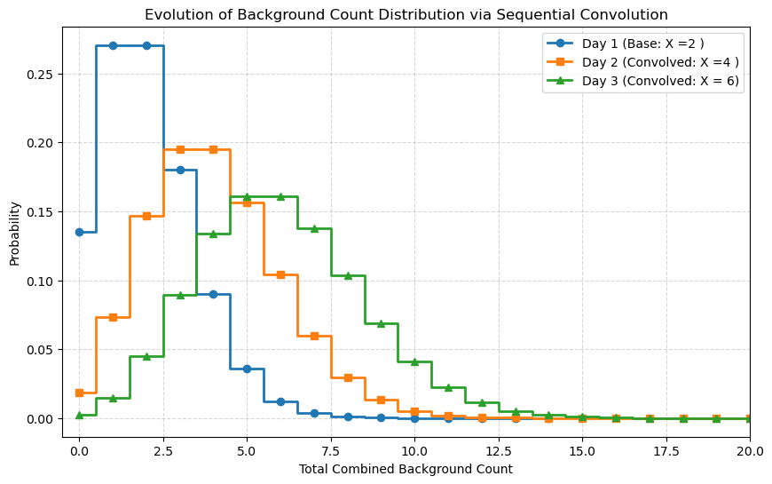

```python
# Problem 1a.
# Average cosmic-ray background X = 2
# Average number of gamma rays emitted by hypothetical source Y = 10

# 1. Define baseline parameters for Day 1 (X = 2)
mu_day = 2
x_day1 = np.arange(0, 15)  # Truncate at 14 since probability drops to near zero
pmf_day1 = poisson.pmf(x_day1, mu_day)

# 2. Convolve Day 1 with itself to find Day 2 (Sum of 2 days)
pmf_day2 = np.convolve(pmf_day1, pmf_day1)
x_day2 = np.arange(0, len(pmf_day2))

# 3. Convolve Day 2 with Day 1 to find Day 3 (Sum of 3 days)
pmf_day3 = np.convolve(pmf_day2, pmf_day1)
x_day3 = np.arange(0, len(pmf_day3))

# 4. Plot the transformation
plt.figure(figsize=(10, 6))

# Plot each PMF as a step/line plot to see the evolution clearly
plt.step(x_day1, pmf_day1, where='mid', label='Day 1 (Base: X =2 )', marker='o', linewidth=2)
plt.step(x_day2, pmf_day2, where='mid', label='Day 2 (Convolved: X =4 )', marker='s', linewidth=2)
plt.step(x_day3, pmf_day3, where='mid', label='Day 3 (Convolved: X = 6)', marker='^', linewidth=2)

plt.title('Evolution of Background Count Distribution via Sequential Convolution')
plt.xlabel('Total Combined Background Count')
plt.ylabel('Probability')
plt.xlim(-0.5, 20)  # Restrict view window to focus on the active data space
plt.grid(True, linestyle='--', alpha=0.5)
plt.legend()
plt.show()
```

When summing over multiple days, you convolve the original distribution with itself just like the dice scenario. The distribution changes from being very right-skewed with a mean of 2 to getting more of a bell-curve shape and a larger total count that increases by 2 with every extra day added.

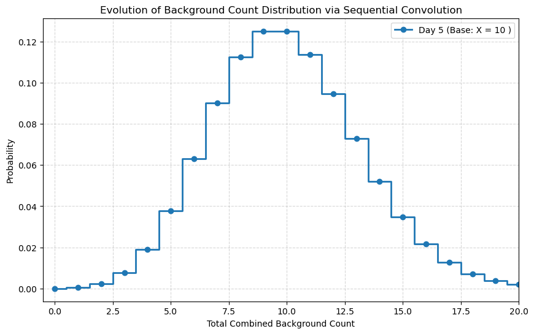

```python
# convolving 3 and 2 to get 5
pmf_day5 = np.convolve(pmf_day3, pmf_day2)
x_day5 = np.arange(0, len(pmf_day5))


plt.figure(figsize=(10, 6))

plt.step(x_day5, pmf_day5, where='mid', label='Day 5 (Base: X = 10 )', marker='o', linewidth=2)
plt.title('Evolution of Background Count Distribution via Sequential Convolution')
plt.xlabel('Total Combined Background Count')
plt.ylabel('Probability')
plt.xlim(-0.5, 20)  # Restrict view window
plt.grid(True, linestyle='--', alpha=0.5)
plt.legend()
plt.show()
```

Problem 1b. After summing over 5 days, the distribution remains a Poisson distribution. This is because the distribution still represents discrete values and is not averaged yet.

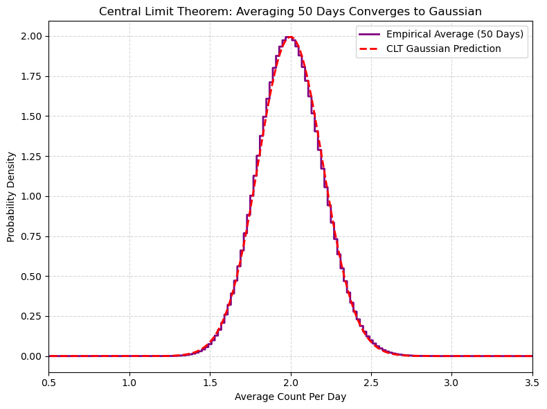

```python
#Problem 1c.

# 1. Setup Parameters & convolutions over 50 days

mu_base = 2         # Base background rate per day
n_days_large = 50   # Number of days to average over to demonstrate central limit theory

# Generate baseline Day 1 PMF (truncated at 14 where probability drops near 0)
x_base = np.arange(0, 15)
pmf_large_sum = poisson.pmf(x_base, mu_base)

# Iteratively convolve over the specified span of days
for _ in range(n_days_large - 1):
    pmf_large_sum = np.convolve(pmf_large_sum, poisson.pmf(x_base, mu_base))


# 2. Transform from sum distribution to a daily average distribution

x_sum_ticks = np.arange(0, len(pmf_large_sum))
x_avg_ticks = x_sum_ticks / n_days_large  # Convert total counts into daily averages

# Theoretical Gaussian metrics according to CLT:
# Mean of averages = base mean. Standard deviation of averages = base std_dev / sqrt(N)
clt_mean = mu_base
clt_std = np.sqrt(mu_base) / np.sqrt(n_days_large)

# Continuous x-axis range for mapping the smooth Gaussian curve
x_gaussian_curve = np.linspace(0, 4, 300)
pdf_gaussian_curve = norm.pdf(x_gaussian_curve, loc=clt_mean, scale=clt_std)

# 3. Plot

plt.figure(figsize=(8, 6))

# Multiply discrete PMF values by N to scale properly into a continuous probability density
plt.step(x_avg_ticks, pmf_large_sum * n_days_large, where='mid', color='purple', lw=2, label=f'Empirical Average ({n_days_large} Days)')
plt.plot(x_gaussian_curve, pdf_gaussian_curve, 'r--', lw=2, label='CLT Gaussian Prediction')

plt.title(f'Central Limit Theorem: Averaging {n_days_large} Days Converges to Gaussian')
plt.xlabel('Average Count Per Day')
plt.ylabel('Probability Density')
plt.xlim(0.5, 3.5)
plt.grid(True, linestyle='--', alpha=0.5)
plt.legend()

plt.tight_layout()
plt.show()
```

When averaging days, the probability distribution smooths out and retains the mean of 2 from the count/X = 2 per day of the first distribution. The distribution is pretty symmetrical and loses the right skew that the initial distributions had. This makes sense with the central limit theorem because now the days are averaged and the distribution is no longer a Poisson distribution as it is no longer discrete. It is converging toward a Gaussian distribution with more days averaged over.

```python
# Problem 1d.
# Count/day = 10
# Days: N = 5

def calculate_observation_sigma(N, Y, mu_bg=2):

    # 1. Total expected background counts
    expected_bg = mu_bg * N

    # 2. Standard deviation of the background counts over N days
    sigma_bg = np.sqrt(expected_bg)

    # 3. Total observed counts
    observed_total = Y * N

    # 4. Calculate sigma (Z-score)
    sigma = (observed_total - expected_bg) / sigma_bg

    print(f"--- Observation Results over {N} Days ---")
    print(f"Expected Background Counts: {expected_bg}")
    print(f"Observed Total Counts:      {observed_total}")
    print(f"Significance of Discovery:  {sigma:.2f} sigma")

    return sigma


# N = 50 days, and assume an observed daily rate of Y = 10 gamma rays/day
_ = calculate_observation_sigma(N=5, Y=10)
```

```
--- Observation Results over 5 Days ---
Expected Background Counts: 10
Observed Total Counts:      50
Significance of Discovery:  12.65 sigma
```

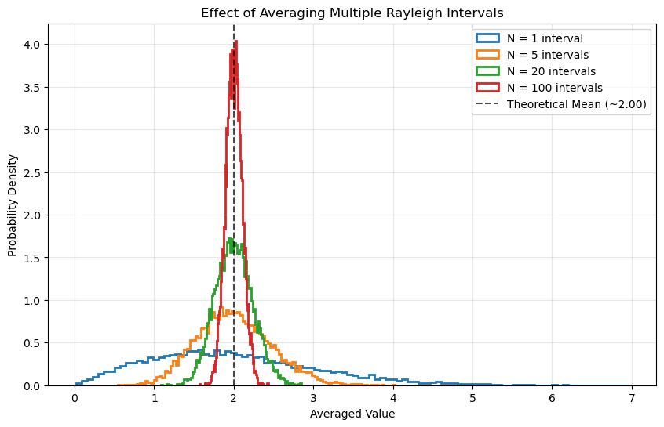

```python
# Problem 2:

# Parameters
sigma = 1.596
num_samples = 10000
intervals_to_test = [1, 5, 20, 100]  # Number of intervals (N) to average over

rng = np.random.default_rng(seed=42)

plt.figure(figsize=(10, 6))

# Generate and plot the distribution for each N
for N in intervals_to_test:
    # Draw an array of shape (num_samples, N) and average across the intervals (axis=1)
    samples = rng.rayleigh(scale=sigma, size=(num_samples, N))
    averaged_samples = np.mean(samples, axis=1)


    plt.hist(averaged_samples, bins=100, density=True, histtype='step',
             lw=2, label=f'N = {N} interval{"s" if N > 1 else ""}')

# Calculate theoretical mean of the base Rayleigh distribution
rayleigh_mean = sigma * np.sqrt(np.pi / 2)
plt.axvline(rayleigh_mean, color='black', linestyle='--', alpha=0.7,
            label=f'Theoretical Mean (~{rayleigh_mean:.2f})')

plt.title('Effect of Averaging Multiple Rayleigh Intervals')
plt.xlabel('Averaged Value')
plt.ylabel('Probability Density')
plt.legend()
plt.grid(True, alpha=0.3)
plt.show()
```

Problem 2b. Yes, the distribution converges toward a Gaussian distribution after a large number of intervals. At about N = 100 is when it starts to get close.

```python
# Problem 3a.

# Width of the background Gaussian distribution: X = 1
# the background appears as a zero-mean gaussian distribution with constant width over the image
# Signal of a given strength (floating point value for pixel brightness): Y = 5

background_sigma = 1.0
signal_S = 5.0

# Version 1: a known pixel/location, so there is only one test.
p_local = norm.sf(signal_S, loc=0, scale=background_sigma)
z_local = norm.isf(p_local)

print(f"Background mean: 0")
print(f"Background standard deviation: {background_sigma:g}")
print(f"Candidate signal: {signal_S:g}")
print(f"Local one-sided p-value: {p_local:.6g}")
print(f"Local significance: {z_local:.3f} sigma")
```

```
Background mean: 0
Background standard deviation: 1
Candidate signal: 5
Local one-sided p-value: 2.86652e-07
Local significance: 5.000 sigma
```

With the values chosen above, a discovery can be claimed

Problem 3b. If I sample a Gaussian distribution 10,000 times, what is the probability that the maximum value out of those 10,000 trials at least a specific value z?

$$P\left(\max(X_1, \ldots, X_{10{,}000}) \geq z\right) = 1 - \left[\Phi\left(\frac{z-\mu}{\sigma}\right)\right]^{10{,}000}$$

With 10,000 trials, a 5 sigma event from part a is much more likely to occur. This is shown below where the sigma value goes down to 2.76 from 5.00 after looking at 10,000 pixels

```python
#Problem 3c

sigma_X = 1
Y = 5
N_pixels = 10000

# 1. Local (single-pixel) significance and p-value
local_sigma = Y / sigma_X  # 4.5
local_p_value = 1 - scipy.stats.norm.cdf(local_sigma)


# Probability of seeing a fluctuation this big in at least one of the 10k pixels
global_p_value = 1 - (1 - local_p_value)**N_pixels

# 3. Convert the global p-value back into a global sigma
global_sigma = scipy.stats.norm.ppf(1 - global_p_value)

print(f"Local Significance:  {local_sigma:.2f} sigma")
print(f"Global p-value:      {global_p_value:.5f}")
print(f"Global Significance: {global_sigma:.2f} sigma")
```

```
Local Significance:  5.00 sigma
Global p-value:      0.00286
Global Significance: 2.76 sigma
```

```python
#Problem 4 look elsewhere effect / trials factor

sigma = 1.0      # width of background Gaussian
N = 10000        # trials factor (number of pixels)

p5 = norm.sf(5)  # one-sided 5-sigma p-value (~2.87e-7)

# A) Version 1: single known pixel
print("4a. signal needed (V1) =", norm.isf(p5) * sigma)

# B) Version 2: global p = p5, so local p = 1 - (1 - p5)^(1/N)
p_local = -np.expm1(np.log1p(-p5) / N)
print("4b. signal needed (V2, N=10k) =", norm.isf(p_local) * sigma)

# C) Penalty for N = 10k
print("4c. extra brightness =", (norm.isf(p_local) - 5) * sigma, "sigma")

# D) Vary the trials factor over orders of magnitude
print("\n4d. N, signal needed for global 5 sigma")
for n in [1, 10, 100, 1e3, 1e4, 1e6, 1e9, 1e12]:
    pl = -np.expm1(np.log1p(-p5) / n)
    print(f"   {n:>8.0e}  {norm.isf(pl) * sigma:.3f}")
```

```
4a. signal needed (V1) = 5.000000000000001
4b. signal needed (V2, N=10k) = 6.550537591305319
4c. extra brightness = 1.5505375913053188 sigma

4d. N, signal needed for global 5 sigma
      1e+00  5.000
      1e+01  5.427
      1e+02  5.824
      1e+03  6.198
      1e+04  6.551
      1e+06  7.207
      1e+09  8.095
      1e+12  8.897
```

The sensitivity penalty for the trials factor is so low (1.55 sigma greater than version 1) because the tail of a Gaussian distribution falls off very quickly, so moving a small amount to the right along the x-axis reduces the probability by several orders of magnitude. A trials factor of N = 10^4 makes the background 10^4 times more likely to produce a signal-like fluctuation, so the signals need to significant enough to cancel out that factor of 10^4 from observing more pixels.

4e. With a different shaped distribution, probabilities at the tail could fall off slower or faster than a Gaussian distribution leading to a difference in the sensitivity penalty of many trials. An exponential distribution as example is skewed to the right and has a longer / larger tail than a Gaussian distribution, and so having a trials factor of N = 10^4 might have a larger impact on the sigma value than it does for the Gaussian distribution above.